# Segmentation Methods 1: Lavielle

[Brazil Move 2024 - UFMS - Campo Grande](https://eligurarie.github.io/BrazilMove2024)

Nicki Barbour and Elie Gurarie

May 22, 2024

# Pick an elk

First, let’s load in our processed data from lab 1.

```r
load("./data/elk_processed.rda")
```

We will use one individual from our data as an example, “YL96”. This individual has some “patches” of residency-like behavior along its track.

```r
myelk <- subset(elk_gps, id == "YL96") |>
  dplyr::mutate(id = as.character(id))

str(myelk)
```

```
## 'data.frame':    4129 obs. of  4 variables:
##  $ datetime: POSIXct, format: "2004-03-29 17:00:00" "2004-03-29 19:02:00" ...
##  $ lon     : num  -116 -116 -116 -116 -116 ...
##  $ lat     : num  51.7 51.8 51.7 51.7 51.7 ...
##  $ id      : chr  "YL96" "YL96" "YL96" "YL96" ...
```

We can use Base R to visualize the track of this individual in space and time, using the methods we learned in lab 1:

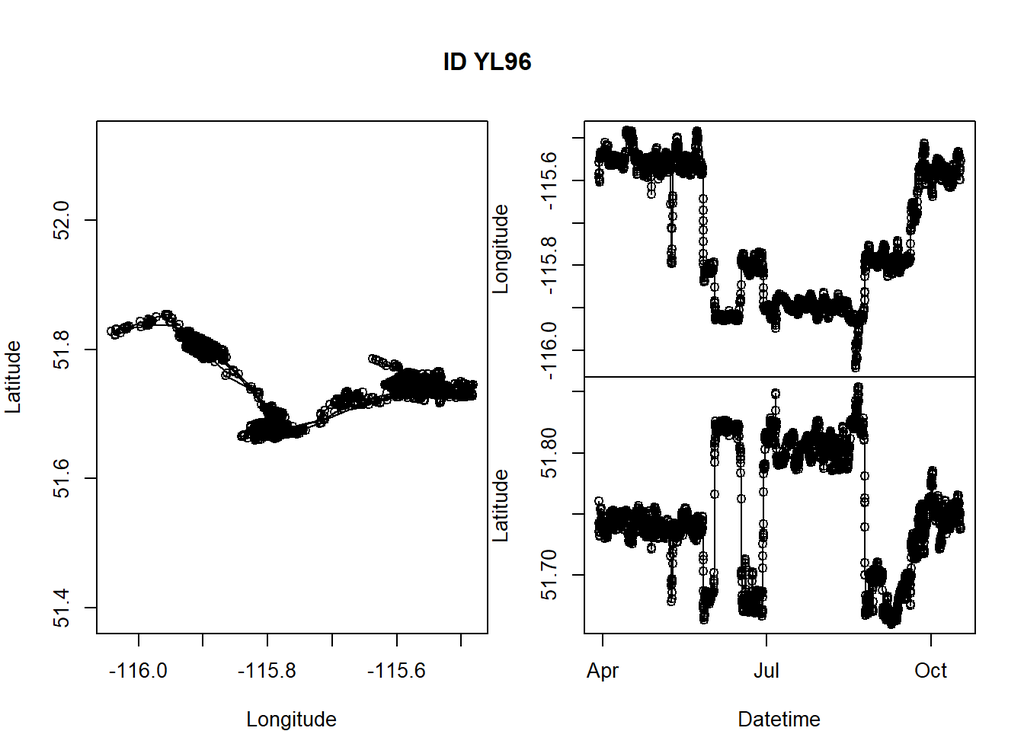

```r
par(mar = c(0,4,0,0), oma = c(4,0,5,2), xpd=NA)
layout(rbind(c(1,2), c(1,3)))
plot(myelk$lon, myelk$lat, asp = 1, type="o", ylab="Latitude", xlab="Longitude")
plot(myelk$datetime, myelk$lon, type="o", xaxt="n", ylab="Longitude", xlab="")
plot(myelk$datetime, myelk$lat, type="o", ylab="Latitude", xlab="Datetime")
title(paste("ID", myelk$id[1]), outer = TRUE)
```

# Lavielle Method

Lavielle’s method identifies behavioral break points by applying a moving window over the timeseries. The optimal number of segments, *k*, in the timeseries is then determined by minimizing the “penalized contrast function” (Lavielle 2005). Break points are determined using the mean, variance, or mean AND variance along the timeseries of the variable of interest (e.g., speed). The assumption is that in each phase, the model for the data is:

$$X = {\cal N}(\mu_i,
\sigma_i)$$

You can perform this analysis on **absolute positions** or on **speeds**.

## Segmenting on positions

Load the `adehabitatLT` package:

```r
require(adehabitatLT)
```

The Lavielle Method is fit using the `laveielle` function, where the user can specify the:

1 - variable from the dataset to distinguish the segments by (here, we will use latitude) 2 - `Lmin` - the minimum number of relocations within a segment 3 - `Kmax` - the maximum number of segments to “try out” 4 - `type` - how to distinguish the segments (mean, variance, or both, “meanvar”)

We can use the visualizations of our track to inform our decisions on these parameters.

```r
elk_lavielle_example <- lavielle(myelk$lat, Lmin = 20, Kmax = 10, type = "mean")
```

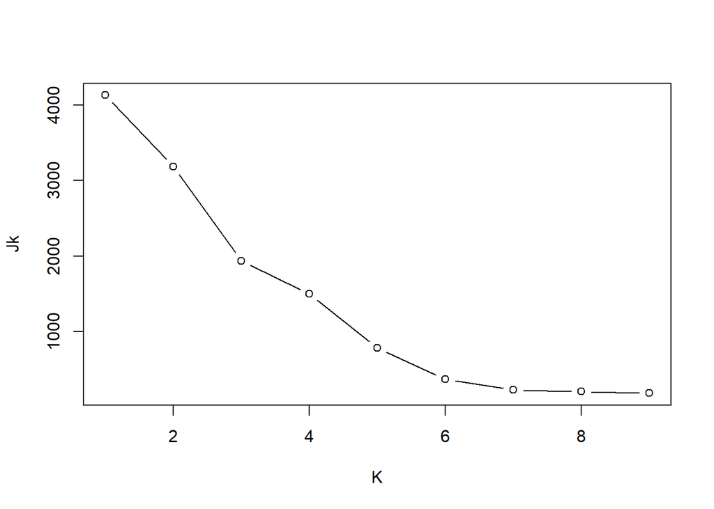

```
##   K            D        Jk
## 1 1          Inf 4128.0000
## 2 2 -0.709449484 3187.2585
## 3 3  1.858270179 1934.8893
## 4 4 -0.629151086 1498.7706
## 5 5  0.669828431  786.2955
## 6 6  0.634875705  368.0444
## 7 7  0.269000322  228.6644
## 8 8  0.003657896  207.4435
## 9 9  0.014817934  187.8293
```

```r
chooseseg(elk_lavielle_example)
```

We can now create a nice plot of these segments, with the change in latitude over time and the red lines dilineating the break points for each segment.

```r
elk_lavielle_example_path <- findpath(elk_lavielle_example, 7)
```

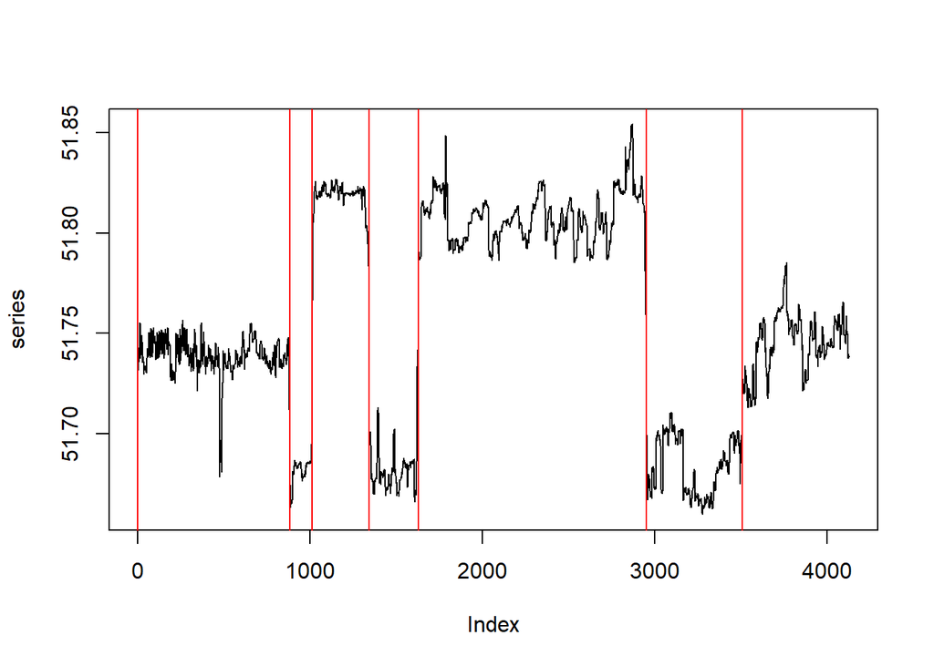

```r
breakpoints <- do.call(rbind, elk_lavielle_example_path)
breakpoints
```

```
##      [,1] [,2]
## [1,]    1  882
## [2,]  883 1014
## [3,] 1015 1342
## [4,] 1343 1628
## [5,] 1629 2951
## [6,] 2952 3509
## [7,] 3510 4129
```

```r
require(plyr)
cuts <- c(breakpoints[,1]-.5, nrow(myelk))
myelk <- myelk |>
  mutate(Row_ID = 1:nrow(myelk),
         phase = cut(Row_ID,
                     breaks = cuts,
                     labels = 1:nrow(breakpoints)))
```

We can visualize the final results using ggplot:

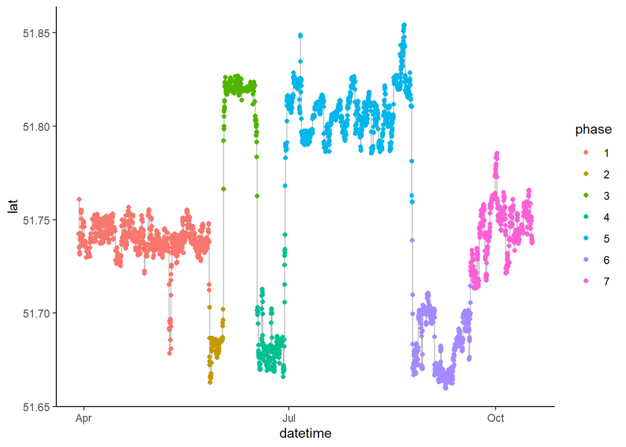

```r
require(ggplot2)
ggplot(data=myelk, aes(x=datetime, y=lat)) +
  geom_path(col = "grey") +
  geom_point(aes(color = phase)) +
  theme_classic()
```

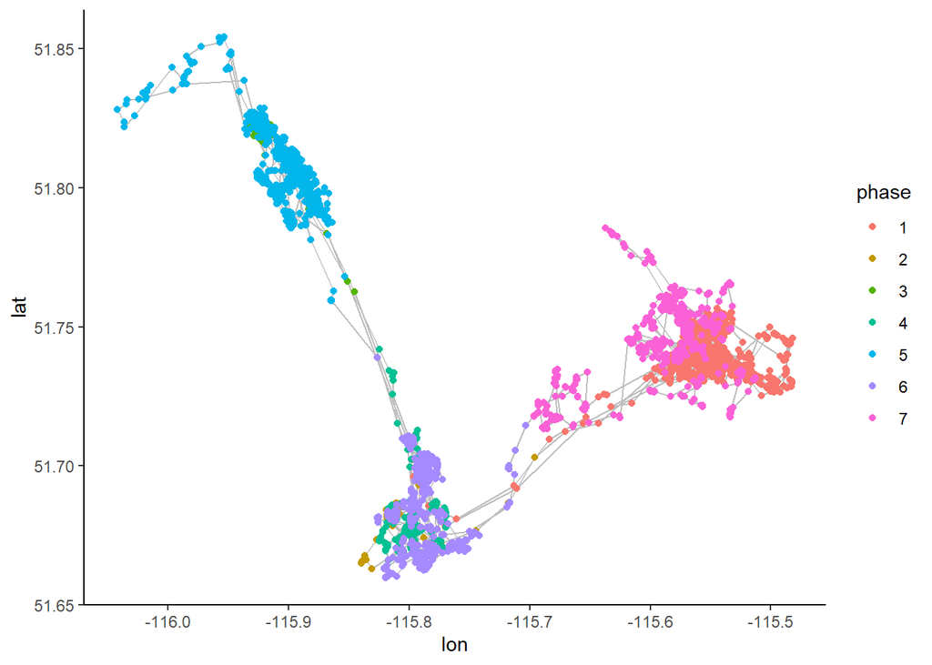

```r
require(ggplot2)
ggplot(data=myelk, aes(x=lon, y=lat)) +
  geom_path(col = "grey") +
  geom_point(aes(color = phase)) +
  theme_classic()
```

## Segmenting on speeds

A problem with this segmentation is that it does not separate transitional movements from the resident movements. It therefore might make more sense to do this on the *velocities* or *speeds*.

First, obtain those velocities, using some of the augmentation code from before:

```r
require(sf)
require(dplyr)

elk_df <- elk_gps |>
  data.frame(elk_sf |> st_transform(32611) |> st_coordinates()) |>
  group_by(id) |>
  mutate(
      Z = X + 1i*Y,
        Step = c(NA, diff(Z)),
        StepLength = Mod(Step),
        dTime = c(NA, difftime(datetime[-1],
                            datetime[-length(datetime)],
                            units = "hours")),
        Speed = StepLength/dTime)

myelk <- subset(elk_df, id == "YL96")
```

Let’s look at the time series of the speed:

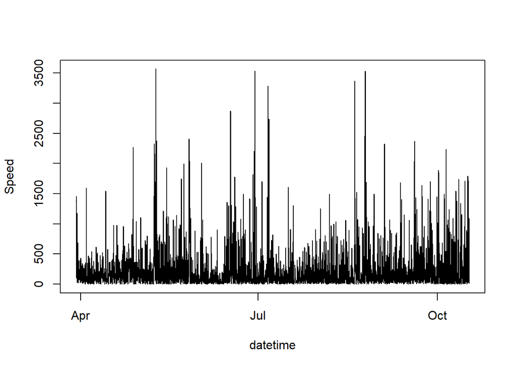

```r
with(myelk,
  plot(datetime, Speed, type = "l"))
```

There is a lot of data here! Also - it is not normal.

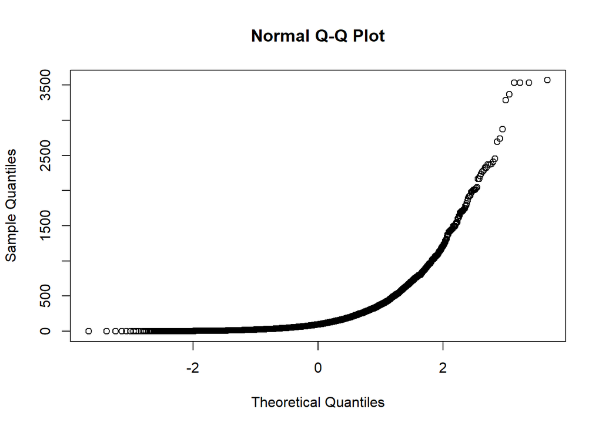

```r
qqnorm(myelk$Speed)
```

The log trandform, on the other hand:

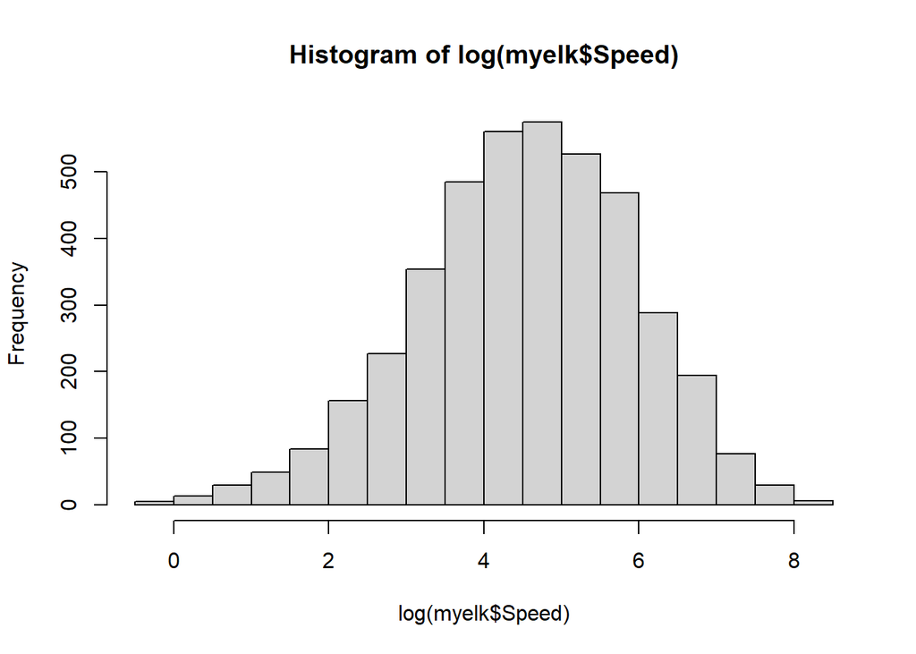

```r
hist(log(myelk$Speed))
```

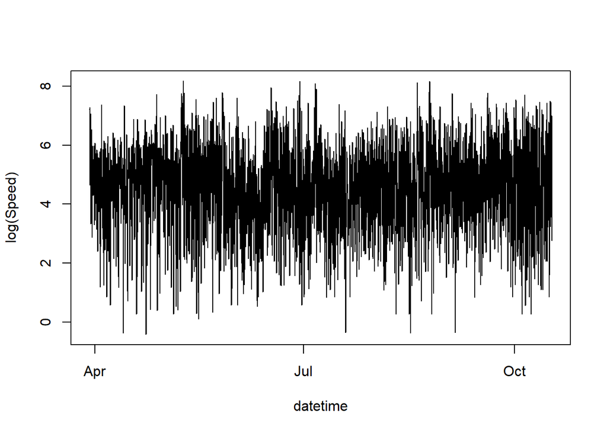

```r
with(myelk, plot(datetime, log(Speed), type = "l"))
```

Ok - are there some significant changes in here?

> NOTE: For reasons that are unclear to me, the segmentation has a hard time with the complete dataset … so I subset an (interesting) portion of the data.

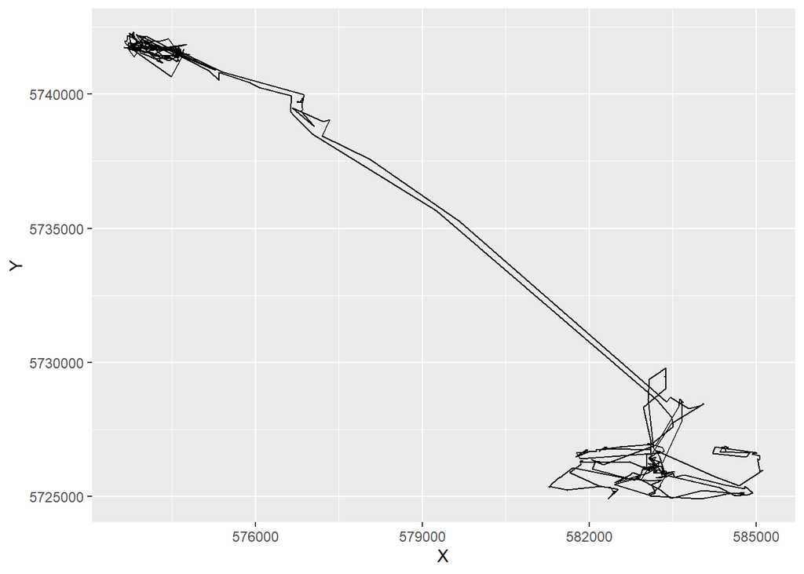

```r
myelk_subset <- myelk[1000:1600,]
ggplot(myelk_subset, aes(X,Y)) + geom_path()
```

```r
LogSpeed <- log(myelk_subset$Speed)[-1]
myelk_speed_lv <-  lavielle(LogSpeed, Lmin = 24, Kmax = 20, type = "mean")
```

Choose the segments:

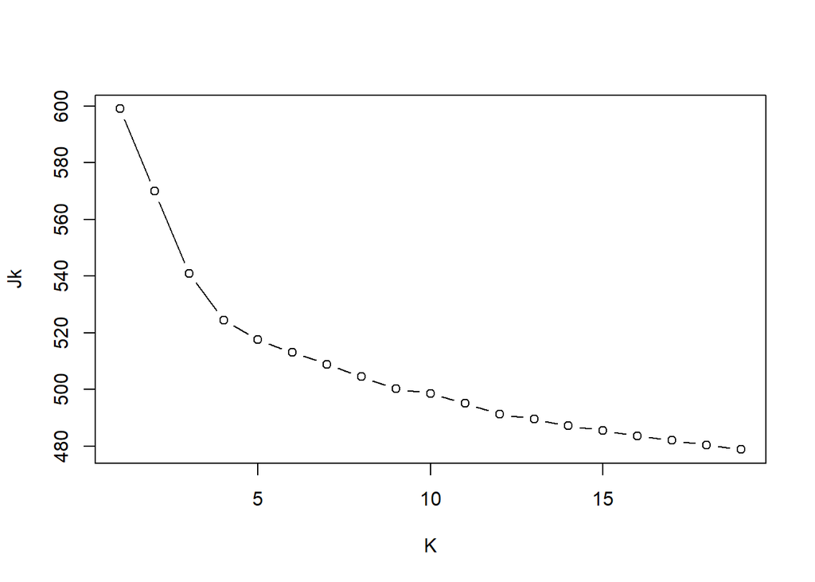

```
##     K           D       Jk
## 1   1         Inf 599.0000
## 2   2  0.01141842 569.9330
## 3   3  1.98088910 540.9388
## 4   4  1.47080930 524.5613
## 5   5  0.40417385 517.5518
## 6   6  0.03930713 513.1167
## 7   7 -0.03099897 508.9318
## 8   8  0.02370299 504.5496
## 9   9  0.39611962 500.3183
## 10 10 -0.27836348 498.6100
## 11 11 -0.03927880 495.1287
## 12 12  0.30253461 491.3973
## 13 13 -0.08932089 489.5927
## 14 14  0.11688541 487.2193
## 15 15 -0.03774008 485.5903
## 16 16  0.03774008 483.7210
## 17 17  0.01041840 482.0920
## 18 18 -0.01041840 480.5294
## 19 19  0.11185802 478.9005
```

```r
chooseseg(myelk_speed_lv)
```

Find the breaks:

```r
elk_segments <- findpath(myelk_speed_lv, 10)
```

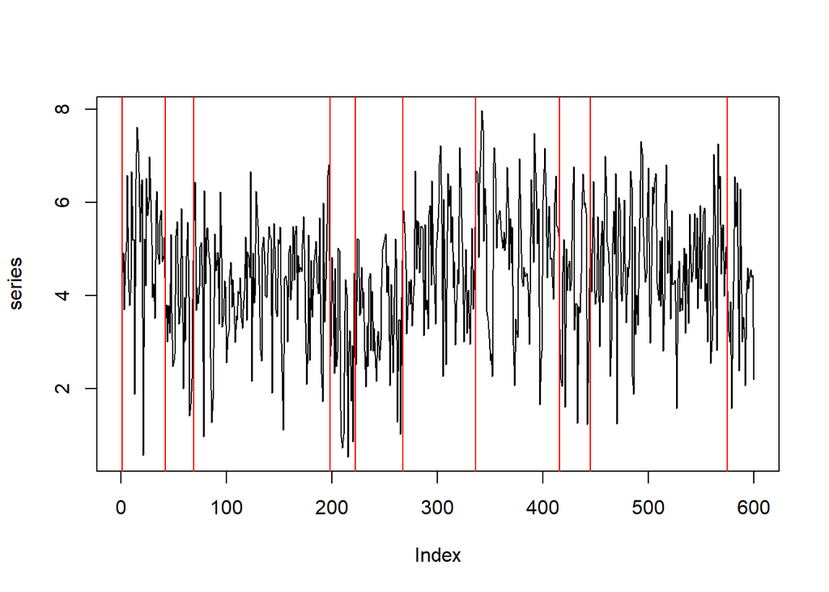

```r
breakpoints <- do.call(rbind, elk_segments)
breakpoints
```

```
##       [,1] [,2]
##  [1,]    1   41
##  [2,]   42   68
##  [3,]   69  197
##  [4,]  198  221
##  [5,]  222  266
##  [6,]  267  335
##  [7,]  336  415
##  [8,]  416  444
##  [9,]  445  574
## [10,]  575  600
```

Add the breaks

```r
require(plyr)
cuts <- c(breakpoints[,1]-.5, nrow(myelk))
myelk_subset <- myelk_subset |>
  mutate(Row_ID = 1:nrow(myelk_subset),
         speedphase = cut(Row_ID,
                     breaks = cuts,
                     labels = 1:nrow(breakpoints)))
```

Visualize the time series

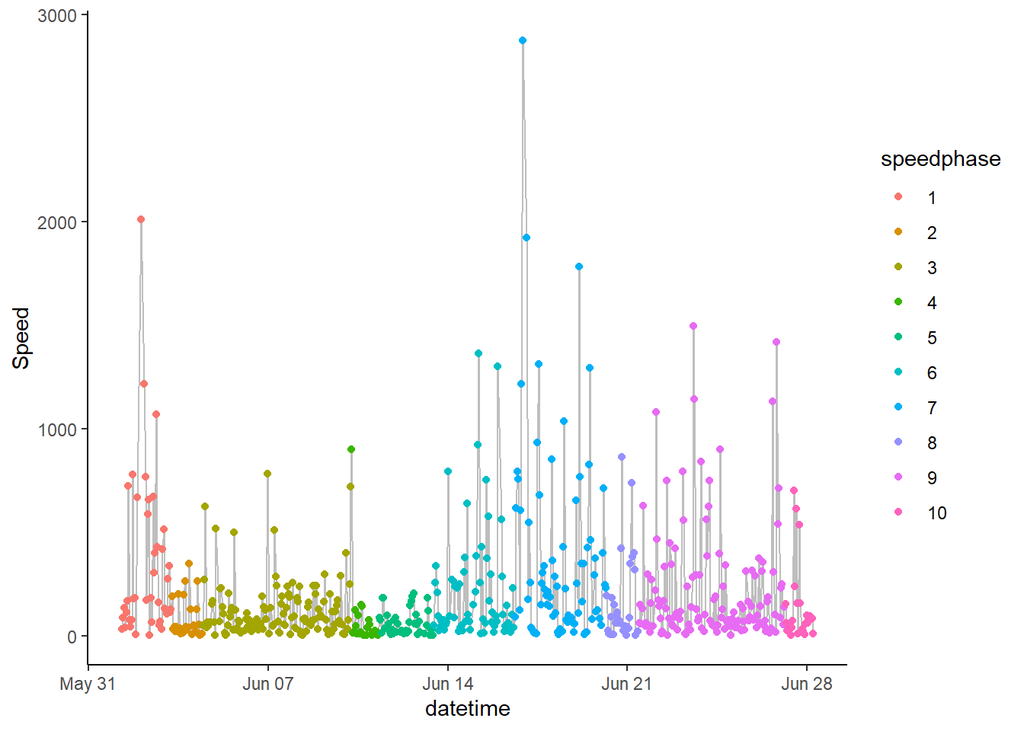

```r
require(ggplot2)
ggplot(data=myelk_subset, aes(x=datetime, y=Speed)) +
  geom_path(col = "grey") +
  geom_point(aes(color = speedphase)) +
  theme_classic()
```

Map with the phases:

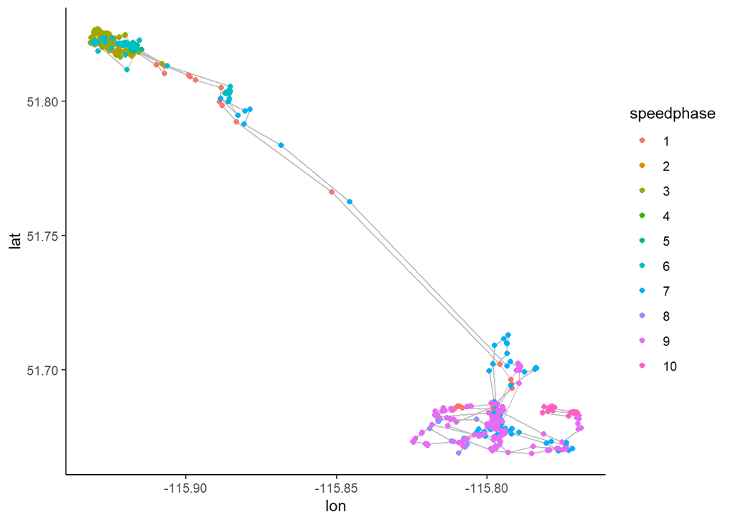

```r
require(ggplot2)
ggplot(data=myelk_subset, aes(x=lon, y=lat)) +
  geom_path(col = "grey") +
  geom_point(aes(color = speedphase)) +
  theme_classic()
```

How do the speeds compare across htese phases?

```r
myelk_subset |> group_by(speedphase) |>
  dplyr::summarize(start = min(datetime),
            end = max(datetime),
            Speed.mean = mean(Speed),
            Speed.sd = sd(Speed))
```

```
## # A tibble: 10 × 5
##    speedphase start               end                 Speed.mean Speed.sd
##    <fct>      <dttm>              <dttm>                   <dbl>    <dbl>
##  1 1          2004-06-01 07:00:00 2004-06-03 05:00:00      346.     404.
##  2 2          2004-06-03 06:00:00 2004-06-04 10:00:00       82.7     97.0
##  3 3          2004-06-04 11:00:00 2004-06-10 05:00:00      121.     136.
##  4 4          2004-06-10 06:00:00 2004-06-11 07:00:00       74.5    182.
##  5 5          2004-06-11 08:00:00 2004-06-13 10:00:00       62.2     59.3
##  6 6          2004-06-13 11:00:00 2004-06-16 14:00:00      217.     278.
##  7 7          2004-06-16 15:02:00 2004-06-20 04:00:00      372.     490.
##  8 8          2004-06-20 05:00:00 2004-06-21 10:00:00      168.     219.
##  9 9          2004-06-21 11:00:00 2004-06-27 03:00:00      221.     286.
## 10 10         2004-06-27 04:00:00 2004-06-28 06:00:00      130.     186.
```